# PSYC 824: Research Issues in Psychology

14/01/2022

[figure not shown]

## Who Am I?

## Matt (*he/him*)

- BA (Hons.) in **Psychology** from Bishop’s University in Sherbrooke
- MA from York University in Toronto (**History of Psychology**)
- PhD from York University in Toronto (**Quantitative Methods**)
- Lecturer in the History, Quantitative, and Theoretical area of Psychology at SFU since January 2018
- Psychological Methods Consulting group Director; Psychometrician
- **Research Interests**: Data visualization, multivariate analysis, simulation.
- **Other Interests**: Cooking/baking, video/board games, Star Wars, skiing, keeping up w/Huxley.
- Email: msigal@sfu.ca

[figure not shown]

## Who Are You?

[figure not shown]

- Your name and pronouns
- Your area of study and main research interests
- Experience with `R`?
- A few interesting facts about you

Please post your introduction to our Canvas discussion page!

## THE COURSE

- Second time - all feedback is very appreciated!
- What are we doing here?

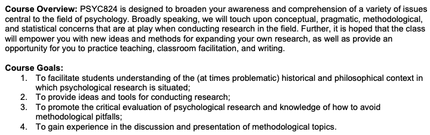

- O_o …that sounds like a *lot*.
- Course goal is to balance **introducing you** to real and relevant issues in psychology, while also providing opportunities to showcase **applied solutions** and techniques to help us navigate them.

[figure not shown]

None of us are experts on all of the course content and some of the material will be challenging. My hope is that we can be open about our expertise and our limitations and use both as a means to open discussion about these issues.

Further, certain aspects of our history as a discipline have been incredibly problematic. Some sensitive topics such as racism, discrimination, and potentially others may arise during the course. I include these topics because they are real and we should be aware of our history and their implications on the work we do today.

I will do my best to treat such topics with sensitivity as they arise. However, if you are finding any of our discussions upsetting, please let me know.

## Class Structure

- Synchronous meetings on Friday mornings from 9:30-12:30 PT.
- As of January 24th, in-person meetings in RCB 6152.
- Weekly readings will be assigned and you are responsible for posting two thoughtful reflections/questions about them by midnight on the Wednesday **before class**.
- Each class will begin with a brief introduction from me, and then be lead by one (or two) “class facilitator(s)”, who will be responsible for leading a lecture and discussion for that week’s topics.
- Most classes will conclude with a brief tutorial or applied demonstration pertinent to the topics we discussed, prepared by me\(^1\).

\(^1\): If you have a particular topic you would like to see a tutorial on, please let me know and I’ll do my best to include it!

## Your Role as Facilitator

- Summarize/integrate/**teach** the week’s material using lectures, demonstrations, and/or other **creative** methods (approx. 25 minutes)
- Guide a **discussion** surrounding the topics drawing upon questions you have come up with alongside those from your classmates (approx. 60 minutes).
- You are welcome to bring in external resources (readings, videos, situations) to help us reflect upon the week’s theme.
- See this link for evaluation details

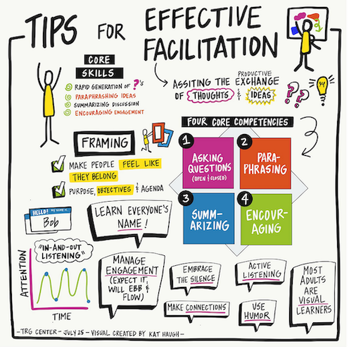

## Your Role as Attendee

- Have read and critically thought about some of the material
- Be respectful of each other and listen actively
- Bring related materials, references, reflections, tangents that promote discussion
- Ask thoughtful questions…

[figure not shown]

## Ways of Reading

Adapted by Dr. N. Myers from “How I Read” by Joseph Dumit

There are many ways we can engage with a text that allow us to pose questions and think about an author’s work. During this course, I would like you to think about how these different styles of reading can be applied to our content.

- **Close Reading**: You pay attention to the specifics of the text. What are the specific modes of writing, grammars, uses of words? How does the author characterize others’ arguments?
- **Constructive Reading**: You attempt to locate coherent arguments from the text and show how it is supported and elaborated within the text. Your aim is to “get” what the author is saying.
- **Deconstructive Reading**: You tend to concentrate on incoherences and contradictions in the text and show how they are generated. Your goal is to get at the underlying motivations that produced these inconsistencies.
- **Positive Reading**: Your aim is to create new concepts or arguments in order to articulate them with current issues.
- **Negative Reading**: Your goal is to point out how errors happen and offer a means to be aware of them and hopefully avoid them in the future.

## Ways of Reading

Adapted by Dr. N. Myers from “How I Read” by Joseph Dumit

- **Generous Reading**: A reading that emphasizes a text’s strengths. A generous reader pulls out a text’s strongest arguments, even if it means constructing them from scattered fragments in the text.
- **Critical Reading**: You emphasize the weaknesses of a text, hold the author responsible for inconsistencies, and usually attempt to tie these problems to the value of the text in general, often implying that these problems raise a general question of the legitimacy or truth-value of the text as a whole.
- **Methodological Reading**: You attend to how the text was made, the research that was done to provide the text, and the work of the construction of the text, typically with the goal of using such methods in your own research.
- **Explicative Reading**: You ask, what does this text say, and how can I use its conclusions in my own writing?
- Among others! We can employ a combination of these reading strategies every time we engage with research.

## Questions to Ask (by Dr. Natasha Myers)

1. What is the author saying? Try to summarize what is being said in your own words. Take careful notes.
2. Organize your notes. If you are a visual learner, make a map. Where do these ideas fit in among others?
3. How is the author making their argument?
4. Who is the author talking to? Think about historical and theoretical context; when was this written, what was going on in the world at that time?
5. Which standing theories are they challenging? What kinds of theories are they pushing against? What distinguishes their theory?
6. What are the political motivations (both hidden and explicit) that might be shaping their argument?
7. What, potentially, are some of the implications of the author’s argument? Here you need to extrapolate and see beyond the text.
8. Look for passages that strike you, that resonate with you, or generate discord for you. Take careful note of places in the text where the writer says something that speaks to you about the world that you already have ideas about. How does the writer challenge, shift, or affirm your views? What new insights does their analysis generate?

## Course Evaluation/Graded Outcomes

1. Class Facilitation: 40%.
2. Class/Canvas Participation: 15%.
3. Discussion Questions: Weekly (except when you are primary facilitator); 15%.
4. Final Paper: Due by 12pm PT on April 11th, 2022; 30%.

The **final paper** for this course will most likely be a **research proposal**, which can serve as a draft of your MA thesis proposal (students who have already completed their thesis proposal/thesis, should contact me to determine an appropriate substitute). An abstract for your final paper is to be submitted by February 15th.

Your paper should include: an introduction, a detailed methods section, and a well-conceived plan for data analysis that includes a power analysis. The introduction must operationally define all variables of interest and include clearly defined goals and hypotheses. The materials section should clearly indicate participants, materials, and procedures that will be employed to test these hypotheses. Finally, the statistical methods section should indicate the specific analyses that will be used to test each hypothesis and prediction. All section must conform to APA publication standards.

It is expected that students will work in conjunction with their advisers on their proposals.

## Research Issues in *Psychology*

> “The scientific study of the human mind and its functions, especially those affecting behavior in a given context.” (Oxford Languages Definition)
- Succinct, descriptive. Shows aims of discipline.
- Hides: the mess!
- How do we measure the invisible?
- How do we confront the incredibly human scandals (the racism, sexism, ableism, homophobia, transphobia, fraud) that come with our discipline?
- What do our tools say about our biases?
- How can we conduct research in a way that promotes good science while respecting our communities?

[video not shown]

What themes/concepts/words are used most consistently by the interviewees? Source: http://www.youtube.com/embed/Fm14F3vabhw

## This Week’s Readings (1/2)

- Jones-Roy, A. (2019, July 24). I’m a data scientist who is skeptical about data. Retrieved from https://qz.com/1664575/is-data-science-legit/

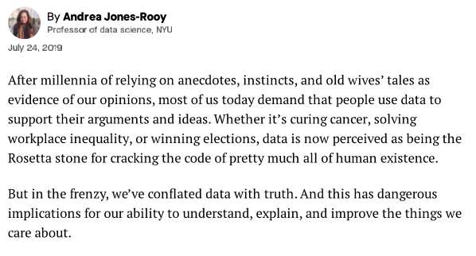

## This Week’s Readings (1/2)

Data is what results when humans want to know something about something, try to *measure* it, and then *combine those measurements* in particular ways.

- So… In what ways can this go wrong?

## Errors in Data

- **Random Errors** (e.g., false positives; issues with instrumentation)
- **Systematic Errors** (some data is consistently making its way into your dataset at the expense of others; e.g., selection bias)
- **Errors of Choosing What to Measure** (when we think we are measuring one thing, but we aren’t; e.g., GPA as “a great measure of someone’s ability to select classes they are guaranteed to ace”)
- **Errors of Exclusion** (populations systematically ignored in datasets)

“…the usefulness of data and science comes not from the fact that it’s perfect and complete, but from the fact that we recognize the limitations of our efforts.”

## “Data doesn’t ‘say’ anything. Humans say things.” –Jones-Roy (2019).

## Reflections on Jones-Roy (2019):

- What is data science? What does it have to do with Psychology?
- What does it mean to conflate data with truth?
- What imperfections come from and with quantification?

[figure not shown]

## This Week’s Readings (2/2)

- Rozin, P. (2009). What kind of empirical research should we publish, fund, and reward? A different perspective. *Perspectives on Psychological Science*, *4*(4), 435-439.

What kind of research gets published in psychological journals?

What gets funded?

[figure not shown]

## Rozin’s Aims for Psychology

- Proposition 1: …to understand how humans and animals behave, think, and feel and how these events influence and are influenced by their material and social environment.
- Proposition 2: …contributions… should… serve the purpose of psychology as indicated in Proposition 1.
- Proposition 3: …potential contributions to psychology… should be evaluated principally in terms of the degree to which they advance our understanding.

## What is happening?

Grant support, publication and rewards seem to be more dependent on:

- methodological sophistication;
- clarity of conclusions; and,
- direct advances in understanding of a well-defined laboratory effect (…[or] demonstration of activation of an area in the brain).

“This focus strongly privileges **hypothesis testing**, **experiments**, and **sophisticated methodologies and statistical analyses**”

## Rozin’s Argument

- Compares what we do to work in the Natural Sciences: research there either focuses on **describing phenomena** or **creating/testing theories to explain these phenomena**, with description preceding hypothesis testing.
- Have we not devoted enough resources to description?

### Criteria for Research:

1. There are many ways to directly or indirectly advance our understanding of psychology.
2. Length of contribution is itself not a criterion. The longer the paper, the more it should accomplish.
3. Elegance and clarity are criteria for publication, but there should be a trade-off with novelty and engagement.
4. The critical criterion is a contribution to understanding.

## Rozin’s Skeletons for Publications:

- Here’s what happens in the world.
- Here is a functional relation between two variables.
- Here’s something interesting that no one has noticed, and it is not easily susceptible to explanation by the principles available to us.
- Here’s something we haven’t studied, but it looks like it can be subsumed under something we already know.
- Hey, someone did this really interesting study decades ago, and no one seems to have noticed it.
- Everyone assumes Effect X, but is X robust and generalizable?
- This is a messy, criticizable experiment reporting something new and interesting.

## Things to Ponder:

- Do you believe psychology has “jumped ahead”? Should 10+ “descriptive studies” be undertaken before we begin crafting theories?
- What type of reading is Rozin doing in his observation of the field?
- “…we need more concern with net progress in the field and how we increase understanding. Negativity dominance is a part of animal and human nature, but it has to be controlled: *a really interesting study with a flaw may be more valuable than a flawless but uninteresting study*”.

## For Next Week

Facilitator Sign-up Sheet is Live: https://tinyurl.com/PSYC824-signups

[figure not shown]

## For Next Week

- Post a blurb about yourself in the “Introductions” thread on Canvas
- Sign-up for your facilitator slots
- Look at the readings below and make sure to post two questions/reflections in the “Lecture 2: Psychology in the Philosophy of Science Questions and Reflections” thread.

**Readings on “Psychology in the Philosophy of Science”:**

- Munsterberg, H. (1893). The new psychology and Harvard’s equipment for teaching it. *Harvard Graduate Magazine*, *1*(2), 201-209.
- Coon, D.J. (1993). Standardizing the subject: Experimental psychologists, introspection, and the quest for a technoscientific ideal. *Technology and Culture*, *34*(4), 757-783.
- Berscheid, E. (1992). A glance back at a quarter century of social psychology. *Journal of Personality and Social Psychology*, *63*(4), 525–533.
- Rozin, P. (2001). Social Psychology and Science: Some Lessons from Solomon Asch. *Personality and Social Psychology Review*, *5*(1), 2–14.